# Project 2 - Teams Up for projects & assignment on Canvas

## Team - Sanmukh Sain Karri, Saetbyeol Choi, Sanyuja Kadam

```python
import pandas as pd
import numpy as np

from sklearn.cluster import KMeans
from kmodes.kmodes import KModes
from kmodes.kprototypes import KPrototypes
from sklearn.neighbors import KNeighborsClassifier
from scipy.cluster.hierarchy import dendrogram, linkage, leaves_list

from sklearn.model_selection import train_test_split
from sklearn.metrics import accuracy_score

from sklearn.manifold import TSNE
from scipy.cluster.hierarchy import fcluster
from sklearn.preprocessing import OneHotEncoder
from sklearn.preprocessing import LabelEncoder

# Import module for data visualization
import seaborn as sns
# import plotly.graph_objects as go
from plotnine import *
import plotnine
import matplotlib.pyplot as plt
%matplotlib inline

plt.style.use('ggplot')

import warnings
warnings.filterwarnings("ignore")
```

# Exploratory Data Analysis

#### 1. Objective of the Proposed Research:

Project Objective: To gather teams that are best suited to preparing assignment reports and projects that match compatibility's and interests. During the project, students analyze their area of interest and their major.

The project provides recommendations for grouping the teams together for students who have interests in similar areas, and they work on the project collaboratively. These students have a variety of skill sets that they can use together, so they can learn from each other as well.

In the project, the professors will receive recommendations on groups of teams based on the points they earned on their last assignment and their project score. This will enable them to assign advanced tasks and identify students who need closer supervision.

Ultimately, we create groups of students based on their purpose is to determine team members.

Stakeholder - Canvas Tool - (https://www.instructure.com/canvas)

Our stakeholder is Canvas, an interactive tool that has feature to help students group together and choose the teamates that could provide better suggestions to the students to join the group and work together. Similarly, the clustering algorithms used can also help the professor to put together the based on their performance level and interests and ccompatibilty. This is instead of putting together random students or manually recognizing students to make the team.

#### Import and Organize the datasets

```python
students_name = pd.read_csv('../input/tech-students-profile-prediction/dataset-tortuga.csv')

survey_results_public = pd.read_csv('../input/survey-results-public/survey_results_public.csv')

Students_Major = pd.read_csv('../input/college-majors/majors-list.csv')[['Major', 'Major_Category']]

students_perf = pd.read_csv('../input/students-performance-in-exams/StudentsPerformance.csv')[['race/ethnicity', 'math score', 'reading score', 'writing score']]

students_perf.rename(columns={'math score':'Assignment_1st','reading score': 'Assignment_2nd','writing score': 'Assignment_3rd','race/ethnicity': 'Class'}, inplace=True)
```

```python
df = students_name[['NAME', 'USER_ID']].iloc[:100];

area_of_interest = ['Business', 'Crime', 'Education', 'Healthcare', 'Marketing', 'Music', 'Sport', 'Travel', 'Food']

df['INTERESTED_PROJECT_AREA'] = np.random.choice(area_of_interest, size=len(df));
```

```python
df = df.reindex(columns=['USER_ID','NAME','INTERESTED_PROJECT_AREA']); df.head()
```

|  | USER_ID | NAME | INTERESTED_PROJECT_AREA |
| --- | --- | --- | --- |
| 0 | 58283940 | Stormy Muto | Food |
| 1 | 1357218 | Carlos Ferro | Education |
| 2 | 63212105 | Robby Constantini | Travel |
| 3 | 23239851 | Paul Mckenny | Crime |
| 4 | 72234478 | Jean Webb | Music |

```python
survey_results_public = survey_results_public[survey_results_public.Age != 'Under 18 years old']
df['AGE_GROUP'] = np.random.choice(survey_results_public.Age.dropna().unique(), size=len(df));

df['EMPLOYMENT_TYPE'] = np.random.choice(survey_results_public.Employment.dropna().unique(), size=len(df));

df['FORMAL_EDUCATION'] = np.random.choice(survey_results_public.FormalEducation.dropna().unique(), size=len(df));

# removed all the users without education as it has no meaning to have mastr education studnets without the unedrgrad points
survey_results_public = survey_results_public[survey_results_public.UndergradMajor != 'I never declared a major']
survey_results_public = survey_results_public[survey_results_public.FormalEducation != 'I never completed any formal education']

# Check the above results
# survey_results_public[survey_results_public.UndergradMajor == 'I never declared a major'].head()
# survey_results_public[survey_results_public.FormalEducation == 'I never completed any formal education'].head()

df['UNDERGRAD_MAJOR'] = np.random.choice(survey_results_public.UndergradMajor.dropna().unique(), size=len(df))

# Age group where EMPLOYMENT_TYPE can be the type 'retired' i.e., below 40-54 years old
nonretire_age_group = ['Under 18 years old', '18 - 24 years old', '25 - 34 years old']
employement_types = ['Not employed, but looking for work', 'Employed full-time', 'Employed part-time', 'Not employed, and not looking for work']
df['EMPLOYMENT_TYPE'][df.AGE_GROUP.isin(nonretire_age_group)] = np.random.choice(employement_types)
```

```python
Students_Major.Major.unique()
Students_Major = Students_Major[Students_Major.Major.isin([
    'COMPUTER SCIENCE', 'COMPUTER PROGRAMMING AND DATA PROCESSING', 'INFORMATION SCIENCES',
    'FINANCE', 'ACCOUNTING',
    'FINE ARTS', 'DRAMA AND THEATER ARTS',
    'MEDICAL TECHNOLOGIES TECHNICIANS', 'HEALTH AND MEDICAL ADMINISTRATIVE SERVICES'
])]
Students_Major = Students_Major[Students_Major.Major_Category.isin(['Computers & Mathematics', 'Health', 'Business', 'Arts'])]

Students_Major = Students_Major.append([Students_Major]*12,ignore_index=True)

Students_Major = Students_Major.sample(frac=1)

df[['UNDERGRAD_MAJOR', 'MAJOR_CATEGORY']] = Students_Major[['Major', 'Major_Category']]
```

# Preview the Dataset

```python
df.head()
```

|  | USER_ID | NAME | INTERESTED_PROJECT_AREA | AGE_GROUP | EMPLOYMENT_TYPE | FORMAL_EDUCATION | UNDERGRAD_MAJOR | MAJOR_CATEGORY |
| --- | --- | --- | --- | --- | --- | --- | --- | --- |
| 0 | 58283940 | Stormy Muto | Food | 45 - 54 years old | Employed part-time | Bachelor’s degree (BA, BS, B.Eng., etc.) | FINE ARTS | Arts |
| 1 | 1357218 | Carlos Ferro | Education | 35 - 44 years old | Independent contractor, freelancer, or self-em... | Other doctoral degree (Ph.D, Ed.D., etc.) | DRAMA AND THEATER ARTS | Arts |
| 2 | 63212105 | Robby Constantini | Travel | 45 - 54 years old | Not employed, and not looking for work | Associate degree | ACCOUNTING | Business |
| 3 | 23239851 | Paul Mckenny | Crime | 18 - 24 years old | Not employed, but looking for work | I never completed any formal education | FINANCE | Business |
| 4 | 72234478 | Jean Webb | Music | 65 years or older | Not employed, but looking for work | Some college/university study without earning ... | COMPUTER PROGRAMMING AND DATA PROCESSING | Computers & Mathematics |

# Summary of the Dataset

```python
df.info()
```

```
<class 'pandas.core.frame.DataFrame'>
RangeIndex: 100 entries, 0 to 99
Data columns (total 8 columns):
 #   Column                   Non-Null Count  Dtype
---  ------                   --------------  -----
 0   USER_ID                  100 non-null    int64
 1   NAME                     100 non-null    object
 2   INTERESTED_PROJECT_AREA  100 non-null    object
 3   AGE_GROUP                100 non-null    object
 4   EMPLOYMENT_TYPE          100 non-null    object
 5   FORMAL_EDUCATION         100 non-null    object
 6   UNDERGRAD_MAJOR          100 non-null    object
 7   MAJOR_CATEGORY           100 non-null    object
dtypes: int64(1), object(7)
memory usage: 6.4+ KB
```

# 2. Data Exploration:

Describes the dataset with code (and text) depicting at 4 different aspects as below.

#### Aspect One: Number of Students that are interested in the project area.

```python
df.INTERESTED_PROJECT_AREA.value_counts().sort_values(ascending=False).head(16)
```

```
Food          17
Travel        15
Sport         13
Music         12
Marketing     10
Healthcare     9
Education      8
Crime          8
Business       8
Name: INTERESTED_PROJECT_AREA, dtype: int64
```

#### Apect Two: Sample group with high skill set assigned by professors personal knowledge

```python
# Range of Points earned for the assignments
rank_A = np.random.randint(75, 100, size = len(df.index))
rank_B = np.random.randint(60, 75, size = len(df.index))
rank_C = np.random.randint(40, 60, size = len(df.index))

df['ASSIGNMENT_POINTS'] = np.random.choice(rank_A, size=len(df))

df['ASSIGNMENT_POINTS'][df['MAJOR_CATEGORY'] == 'Computers & Mathematics'] = np.random.choice(rank_A, size=len(df))

df['ASSIGNMENT_POINTS'][df['MAJOR_CATEGORY'] == 'Health'] = np.random.choice(rank_B, size=len(df))

df['ASSIGNMENT_POINTS'][df['MAJOR_CATEGORY'] == 'Business'] = np.random.choice(rank_B, size=len(df))

df['ASSIGNMENT_POINTS'][df['MAJOR_CATEGORY'] == 'Arts'] = np.random.choice(rank_C, size=len(df))
```

```python
df[((df['INTERESTED_PROJECT_AREA'] == 'Business') & (df['MAJOR_CATEGORY'] == 'Computers & Mathematics'))
      & (df['EMPLOYMENT_TYPE'] == 'Employed part-time')
      & (df['ASSIGNMENT_POINTS'] > df['ASSIGNMENT_POINTS'].quantile(0.5))
  ]
```

|  | USER_ID | NAME | INTERESTED_PROJECT_AREA | AGE_GROUP | EMPLOYMENT_TYPE | FORMAL_EDUCATION | UNDERGRAD_MAJOR | MAJOR_CATEGORY | ASSIGNMENT_POINTS |
| --- | --- | --- | --- | --- | --- | --- | --- | --- | --- |

#### Aspect Three: The amount of students from different background and employement types

```python
print(df.groupby(['MAJOR_CATEGORY', 'EMPLOYMENT_TYPE'])['UNDERGRAD_MAJOR', 'EMPLOYMENT_TYPE'].size().groupby(level=0).max())

print()
print(df.groupby(['INTERESTED_PROJECT_AREA'])['MAJOR_CATEGORY'].size().groupby(level=0).max())
```

```
MAJOR_CATEGORY
Arts                       10
Business                   10
Computers & Mathematics    18
Health                     10
dtype: int64

INTERESTED_PROJECT_AREA
Business       8
Crime          8
Education      8
Food          17
Healthcare     9
Marketing     10
Music         12
Sport         13
Travel        15
Name: MAJOR_CATEGORY, dtype: int64
```

> Shows the amount of students from different education background.

#### Aspect Four: Students mean score earned on project that are interested in the area of project

```python
# Project scores assigned aggregated by ranks A, B and C
df['PROJECT_SCORE'] = np.random.choice([*rank_A, *rank_B, *rank_C], size=len(df))
```

```python
df.groupby('INTERESTED_PROJECT_AREA')[['PROJECT_SCORE']].mean().sort_values(['PROJECT_SCORE'], ascending=False)
```

| INTERESTED_PROJECT_AREA | PROJECT_SCORE |
| --- | --- |
| Healthcare | 73.000000 |
| Music | 71.916667 |
| Travel | 71.866667 |
| Education | 71.500000 |
| Business | 70.125000 |
| Food | 68.764706 |
| Sport | 68.307692 |
| Crime | 62.875000 |
| Marketing | 61.800000 |

> Above results shows the amount of students that can work together if evaluated based on the mean value of scores earned by group of students. Professor can have plenty amount of students to group together based on their interested areas.

# 3. Data Cleaning:

Clean the data, removing rows and columns that have no useful information or no information at all.

```python
# Check for null values in the dataset
df.isna().any()
```

```
USER_ID                    False
NAME                       False
INTERESTED_PROJECT_AREA    False
AGE_GROUP                  False
EMPLOYMENT_TYPE            False
FORMAL_EDUCATION           False
UNDERGRAD_MAJOR            False
MAJOR_CATEGORY             False
ASSIGNMENT_POINTS          False
PROJECT_SCORE              False
dtype: bool
```

> As it shows above there are no null values in the dataset since it was ignored at the beginning of dataset preparation but we still performed the sanity check.

```python
len(df['USER_ID'].unique())
```

```
100
```

```python
df = df.drop(['USER_ID'], axis=1)
```

```python
df.AGE_GROUP = df.AGE_GROUP.str.replace(' years old', '')

df.AGE_GROUP = df.AGE_GROUP.str.replace(' years or older', '-75')

df.AGE_GROUP = df.AGE_GROUP.str.replace(' ', '')

df.AGE_GROUP.unique()
```

```
array(['45-54', '35-44', '18-24', '65-75', '55-64', '25-34'], dtype=object)
```

> Cleaned age group values for range encoding used for the kNN model

#### Get location data organized

```python
# Countries by continents
asia_continent = ['India', 'Japan', 'South Korea', 'China', 'Singapore']
africa_continent = ['South Africa', 'Kenya', 'Nigeria', 'Morocco', 'Algeria']
north_america_continent = ['Canada', 'United States', 'Mexico', 'Cuba', 'Costa Rica']
europe_continent = ['United Kingdom', 'Italy', 'Germany', 'France', 'Spain']
continents = [asia_continent, africa_continent, north_america_continent, europe_continent]
countries = [*asia_continent, *africa_continent, *north_america_continent, *europe_continent]

df['COUNTRY'] = np.random.choice(countries, size=len(df));
```

> Cleaned the countries and assigned to users based on continents that will help the analysis and cluster model perform better.

# 4. Adaptation:

```python
# Range of Points earned for the assignments
rank_A = np.random.randint(75, 100, size = len(df.index))
rank_B = np.random.randint(60, 75, size = len(df.index))
rank_C = np.random.randint(40, 60, size = len(df.index))

df['ASSIGNMENT_POINTS'] = np.random.choice(rank_A, size=len(df))

df['ASSIGNMENT_POINTS'][df['MAJOR_CATEGORY'] == 'Computers & Mathematics'] = np.random.choice(rank_A, size=len(df))

df['ASSIGNMENT_POINTS'][df['MAJOR_CATEGORY'] == 'Health'] = np.random.choice(rank_B, size=len(df))

df['ASSIGNMENT_POINTS'][df['MAJOR_CATEGORY'] == 'Business'] = np.random.choice(rank_B, size=len(df))

df['ASSIGNMENT_POINTS'][df['MAJOR_CATEGORY'] == 'Arts'] = np.random.choice(rank_C, size=len(df))
```

```python
# Project scores assigned aggregated by ranks A, B and C
df['PROJECT_SCORE'] = np.random.choice([*rank_A, *rank_B, *rank_C], size=len(df))

df[['NAME', 'ASSIGNMENT_POINTS', 'PROJECT_SCORE']].set_index('NAME').head()
```

| NAME | ASSIGNMENT_POINTS | PROJECT_SCORE |
| --- | --- | --- |
| Stormy Muto | 42 | 68 |
| Carlos Ferro | 54 | 58 |
| Robby Constantini | 64 | 59 |
| Paul Mckenny | 60 | 40 |
| Jean Webb | 80 | 49 |

```python
df.set_index('NAME').head()
```

| NAME | INTERESTED_PROJECT_AREA | AGE_GROUP | EMPLOYMENT_TYPE | FORMAL_EDUCATION | UNDERGRAD_MAJOR | MAJOR_CATEGORY | ASSIGNMENT_POINTS | PROJECT_SCORE | COUNTRY |
| --- | --- | --- | --- | --- | --- | --- | --- | --- | --- |
| Stormy Muto | Food | 45-54 | Employed part-time | Bachelor’s degree (BA, BS, B.Eng., etc.) | FINE ARTS | Arts | 42 | 68 | United Kingdom |
| Carlos Ferro | Education | 35-44 | Independent contractor, freelancer, or self-em... | Other doctoral degree (Ph.D, Ed.D., etc.) | DRAMA AND THEATER ARTS | Arts | 54 | 58 | United Kingdom |
| Robby Constantini | Travel | 45-54 | Not employed, and not looking for work | Associate degree | ACCOUNTING | Business | 64 | 59 | United Kingdom |
| Paul Mckenny | Crime | 18-24 | Not employed, but looking for work | I never completed any formal education | FINANCE | Business | 60 | 40 | Germany |
| Jean Webb | Music | 65-75 | Not employed, but looking for work | Some college/university study without earning ... | COMPUTER PROGRAMMING AND DATA PROCESSING | Computers & Mathematics | 80 | 49 | Cuba |

# 5. Descriptive Static Visualization:

#### 1 Visualization over students interested in project area

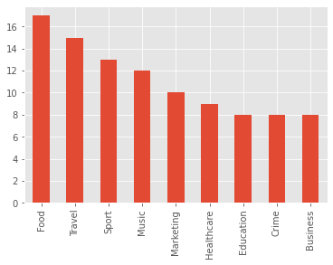

```python
df['INTERESTED_PROJECT_AREA'].value_counts().plot(kind='bar')
```

#### 2. Graph points of students on INTERESTED_PROJECT_AREA VS ASSIGNMENT_POINTS

```python
df.columns
```

```
Index(['NAME', 'INTERESTED_PROJECT_AREA', 'AGE_GROUP', 'EMPLOYMENT_TYPE',
       'FORMAL_EDUCATION', 'UNDERGRAD_MAJOR', 'MAJOR_CATEGORY',
       'ASSIGNMENT_POINTS', 'PROJECT_SCORE', 'COUNTRY'],
      dtype='object')
```

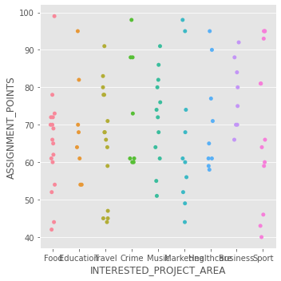

```python
plt.figure(figsize=(10,5))

# plt.scatter(list(df.ASSIGNMENT_POINTS.values),list(df.INTERESTED_PROJECT_AREA.values),color='r')
sns.catplot(data=df, x="INTERESTED_PROJECT_AREA", y="ASSIGNMENT_POINTS")

# Show the graph
plt.show()
```

> The graph depicts the correlation between the students that are interested in project are with what they have earned in the previous projects.

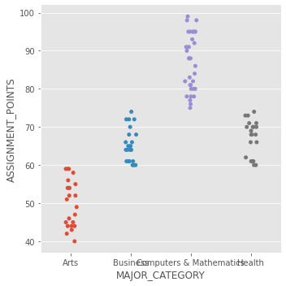

```python
plt.figure(figsize=(10,5))

sns.catplot(data=df, x="MAJOR_CATEGORY", y="ASSIGNMENT_POINTS")

# Show the graph
plt.show()
```

> The above graph depicts the correlation between the students from different background with what scores they have earned in the previous assignments.

#### 3. Visualization on Project Score based on the students interested prject area

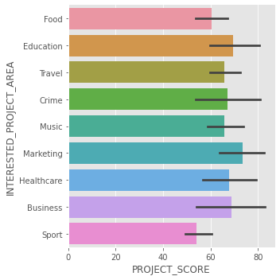

```python
sns.catplot(data=df, x="PROJECT_SCORE", y="INTERESTED_PROJECT_AREA", kind="bar")
```

> The above graph shows the project score on interested are for the professor to decide which area has earned high score and can have advance tasks assigned.

#### 4. Shows the visualization of ASSIGNMENT_POINTS and PROJECT_SCORE earned by the students

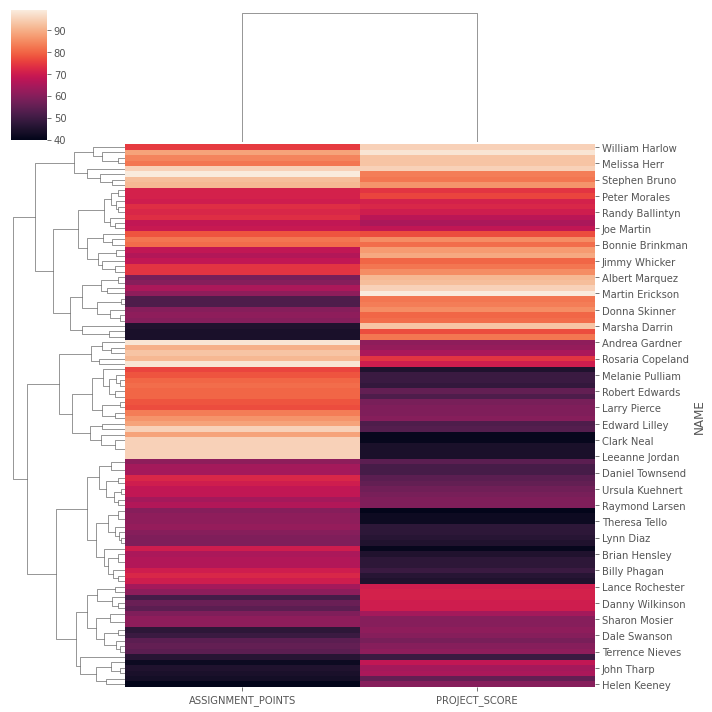

```python
# Default plot
sns.clustermap(df.set_index('NAME')[['ASSIGNMENT_POINTS', 'PROJECT_SCORE']])

# Show the graph
plt.show()
```

> The graph above depicts the students earned points and scored on the previous project and shows the relation between them by the dendrogram.

# Transform categorical data into integer encoding

#### Label Encoding

```python
le = LabelEncoder()

# Declare feature vectors
X = df.copy()

X['INTERESTED_PROJECT_AREA'] = le.fit_transform(X['INTERESTED_PROJECT_AREA'])
X['AGE_GROUP'] = le.fit_transform(X['AGE_GROUP'])
X['EMPLOYMENT_TYPE'] = le.fit_transform(X['EMPLOYMENT_TYPE'])
X['UNDERGRAD_MAJOR'] = le.fit_transform(X['UNDERGRAD_MAJOR'])
X['FORMAL_EDUCATION'] = le.fit_transform(X['FORMAL_EDUCATION'])
X['MAJOR_CATEGORY'] = le.fit_transform(X['MAJOR_CATEGORY'])
X['COUNTRY'] = le.fit_transform(X['COUNTRY'])

X.head()
```

|  | NAME | INTERESTED_PROJECT_AREA | AGE_GROUP | EMPLOYMENT_TYPE | FORMAL_EDUCATION | UNDERGRAD_MAJOR | MAJOR_CATEGORY | ASSIGNMENT_POINTS | PROJECT_SCORE | COUNTRY |
| --- | --- | --- | --- | --- | --- | --- | --- | --- | --- | --- |
| 0 | Stormy Muto | 3 | 3 | 1 | 1 | 5 | 0 | 42 | 68 | 18 |
| 1 | Carlos Ferro | 2 | 2 | 2 | 4 | 3 | 0 | 54 | 58 | 18 |
| 2 | Robby Constantini | 8 | 3 | 3 | 0 | 0 | 1 | 64 | 59 | 18 |
| 3 | Paul Mckenny | 1 | 0 | 4 | 2 | 4 | 1 | 60 | 40 | 6 |
| 4 | Jean Webb | 6 | 5 | 4 | 8 | 1 | 2 | 80 | 49 | 4 |

# K Means on Label Encoding

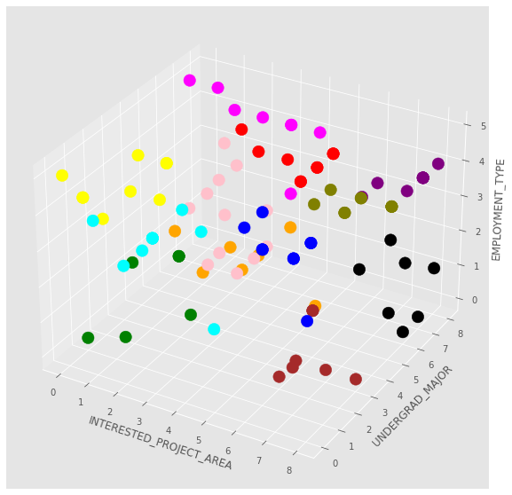

```python
k = 12
model = KMeans(n_clusters = k)
model.fit(X[['INTERESTED_PROJECT_AREA', 'UNDERGRAD_MAJOR', 'EMPLOYMENT_TYPE']])

from mpl_toolkits.mplot3d import Axes3D
colormap = np.array(['yellow', 'red', 'blue','magenta','black','orange','purple','brown','green','pink', 'olive', 'cyan', 'teal'])

fig = plt.figure(figsize=(10, 10))
ax = fig.add_subplot(111, projection='3d')

ax.scatter(xs = X.INTERESTED_PROJECT_AREA, ys = X.UNDERGRAD_MAJOR, zs = X.EMPLOYMENT_TYPE,
           s= 180, depthshade = False, c = colormap[model.labels_])

ax.set_xlabel('INTERESTED_PROJECT_AREA')
ax.set_ylabel('UNDERGRAD_MAJOR')
ax.set_zlabel('EMPLOYMENT_TYPE')

plt.show()
```

#### One Hot Encoding

```python
one_hot_encoded_data = pd.get_dummies(df, columns = ['INTERESTED_PROJECT_AREA'])

one_hot_encoded_data = one_hot_encoded_data.loc[:, ~one_hot_encoded_data.columns.isin(['INTERESTED_PROJECT_AREA', 'AGE_GROUP', 'WORK_STATUS', 'EMPLOYMENT_TYPE', 'FORMAL_EDUCATION', 'UNDERGRAD_MAJOR', 'MAJOR_CATEGORY', 'ASSIGNMENT_POINTS', 'PROJECT_SCORE', 'COUNTRY'])];

one_hot_encoded_data = one_hot_encoded_data.set_index('NAME');

one_hot_encoded_data.head()
```

| NAME | INTERESTED_PROJECT_AREA_Business | INTERESTED_PROJECT_AREA_Crime | INTERESTED_PROJECT_AREA_Education | INTERESTED_PROJECT_AREA_Food | INTERESTED_PROJECT_AREA_Healthcare | INTERESTED_PROJECT_AREA_Marketing | INTERESTED_PROJECT_AREA_Music | INTERESTED_PROJECT_AREA_Sport | INTERESTED_PROJECT_AREA_Travel |
| --- | --- | --- | --- | --- | --- | --- | --- | --- | --- |
| Stormy Muto | 0 | 0 | 0 | 1 | 0 | 0 | 0 | 0 | 0 |
| Carlos Ferro | 0 | 0 | 1 | 0 | 0 | 0 | 0 | 0 | 0 |
| Robby Constantini | 0 | 0 | 0 | 0 | 0 | 0 | 0 | 0 | 1 |
| Paul Mckenny | 0 | 1 | 0 | 0 | 0 | 0 | 0 | 0 | 0 |
| Jean Webb | 0 | 0 | 0 | 0 | 0 | 0 | 1 | 0 | 0 |

# 6. Step-by-step hierarchical clustering

# Hierarchical Label encoding

The idea that interests, majors, and employment types are correlated is applied. And they are all categorical so label encoded data were used for hierarchical clustering. All categorical values have converted into an integer value as below.

```python
X_sel = X[['INTERESTED_PROJECT_AREA', 'UNDERGRAD_MAJOR', 'EMPLOYMENT_TYPE']]; X_sel.head()
```

|  | INTERESTED_PROJECT_AREA | UNDERGRAD_MAJOR | EMPLOYMENT_TYPE |
| --- | --- | --- | --- |
| 0 | 3 | 5 | 1 |
| 1 | 2 | 3 | 2 |
| 2 | 8 | 0 | 3 |
| 3 | 1 | 4 | 4 |
| 4 | 6 | 1 | 4 |

```python
#### Leave-One-Out Encoding (LOO Encoding)
import category_encoders as ce
loo_encoder = ce.LeaveOneOutEncoder(cols=['INTERESTED_PROJECT_AREA', 'AGE_GROUP', 'EMPLOYMENT_TYPE', 'FORMAL_EDUCATION', 'UNDERGRAD_MAJOR', 'MAJOR_CATEGORY', 'COUNTRY'], sigma=0.05)
loo_encoder.fit(df, list(range(0, 100)))
X_encoded = loo_encoder.transform(df)

X_sel = X_encoded[['INTERESTED_PROJECT_AREA', 'UNDERGRAD_MAJOR', 'EMPLOYMENT_TYPE']]; X_sel.head()
```

[output not shown]

# 7. Dendrogram

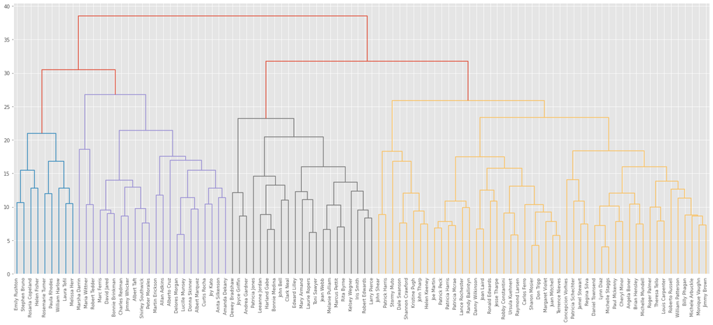

```python
Z = linkage(X.set_index('NAME').head(100), 'average')
plt.figure(figsize=(25, 10))
D = dendrogram(Z=Z, orientation="top", leaf_font_size=9, labels = X.set_index('NAME').head(100).index)
```

```python
k=34
dend_clusters = fcluster(Z, k, criterion='maxclust')
dend_clusters
```

```
array([25, 29, 28, 32, 21,  1,  2, 13, 34, 32, 27,  8, 34, 20, 34,  4, 32,
       28, 23, 24, 15, 26,  8, 21, 20, 31,  9, 29, 27, 30, 32, 18,  1, 20,
       29, 10, 29, 27, 32,  9, 22, 21, 16, 29, 26, 29, 12, 33, 32,  5, 17,
       10, 11, 26,  6, 12, 33, 14, 20,  3, 22, 30, 26, 24, 24, 26, 32, 17,
        8, 17, 12, 10, 24, 33, 13, 32, 19, 22, 16, 26, 34,  7,  6, 14, 27,
        4, 16, 21, 28, 34, 24, 12, 22, 30, 18,  3,  2, 11, 34, 23],
      dtype=int32)
```

> Based on the converted data, hierarchical clustering is implemented in agglomerative way and the result is shown as dendrogram above.

#### Top clustered result

```python
for i in range(1, 3):
    print("\nCluster", i)
    display(df.iloc[X_sel.head(100)[dend_clusters == i].index])
#     display(X_sel.head(100)[dend_clusters == i])
```

```
Cluster 1
```

|  | NAME | INTERESTED_PROJECT_AREA | AGE_GROUP | EMPLOYMENT_TYPE | FORMAL_EDUCATION | UNDERGRAD_MAJOR | MAJOR_CATEGORY | ASSIGNMENT_POINTS | PROJECT_SCORE | COUNTRY |
| --- | --- | --- | --- | --- | --- | --- | --- | --- | --- | --- |
| 5 | Emily Rushton | Food | 65-75 | Employed part-time | Primary/elementary school | COMPUTER SCIENCE | Computers & Mathematics | 99 | 83 | Morocco |
| 32 | Stephen Bruno | Business | 65-75 | Not employed, and not looking for work | Associate degree | COMPUTER SCIENCE | Computers & Mathematics | 92 | 82 | India |

```
Cluster 2
```

|  | NAME | INTERESTED_PROJECT_AREA | AGE_GROUP | EMPLOYMENT_TYPE | FORMAL_EDUCATION | UNDERGRAD_MAJOR | MAJOR_CATEGORY | ASSIGNMENT_POINTS | PROJECT_SCORE | COUNTRY |
| --- | --- | --- | --- | --- | --- | --- | --- | --- | --- | --- |
| 6 | Rosaria Copeland | Music | 45-54 | Not employed, and not looking for work | Professional degree (JD, MD, etc.) | INFORMATION SCIENCES | Computers & Mathematics | 91 | 74 | Costa Rica |
| 96 | Helen Fisher | Travel | 25-34 | Not employed, but looking for work | Secondary school (e.g. American high school, G... | INFORMATION SCIENCES | Computers & Mathematics | 91 | 86 | Algeria |

> On the result, students with similar types are grouped into each group and the cluster shows strong connection related on the major category. But it’s not considered the best model so we did K-Means for the next step.

# 8. Step-by-step K-means

#### ONE HOT ENCODING

One-hot encoding converts the categorical data into numeric data by splitting the column into multiple columns. The numbers are replaced by 1s and 0s, depending on which column has what value.

```python
df_hot = df.copy();

df_hot = df_hot.set_index('NAME');

df_hot_sel = df_hot[['INTERESTED_PROJECT_AREA', 'UNDERGRAD_MAJOR']].iloc[:100];

df_hot_sel.head()
```

| NAME | INTERESTED_PROJECT_AREA | UNDERGRAD_MAJOR |
| --- | --- | --- |
| Stormy Muto | Food | FINE ARTS |
| Carlos Ferro | Education | DRAMA AND THEATER ARTS |
| Robby Constantini | Travel | ACCOUNTING |
| Paul Mckenny | Crime | FINANCE |
| Jean Webb | Music | COMPUTER PROGRAMMING AND DATA PROCESSING |

```python
# checking features
cat = df_hot_sel.select_dtypes(include='O').keys()
# display variabels
cat
```

```
Index(['INTERESTED_PROJECT_AREA', 'UNDERGRAD_MAJOR'], dtype='object')
```

Finding unique values

```python
# unique values in each columns
for x in df_hot_sel.columns:
    #prinfting unique values
    print(x ,':', len(df_hot_sel[x].unique()))
```

```
INTERESTED_PROJECT_AREA : 9
UNDERGRAD_MAJOR : 9
```

```python
# finding the top 16 categories
df_hot_sel.INTERESTED_PROJECT_AREA.value_counts().sort_values(ascending=False).head(16)
```

```
Food          17
Travel        15
Sport         13
Music         12
Marketing     10
Healthcare     9
Education      8
Crime          8
Business       8
Name: INTERESTED_PROJECT_AREA, dtype: int64
```

```python
# put categorical variables in a list
categorical_vars = ["INTERESTED_PROJECT_AREA", "UNDERGRAD_MAJOR"]

# instantiate the one hot encoder
one_hot_encoder = OneHotEncoder(sparse=False, drop = "first")
```

#### Apply the OHE treatment to the data

```python
# apply the one hot encoder logic
encoder_vars_array = one_hot_encoder.fit_transform(df_hot_sel[categorical_vars])

# create object for the feature names using the categorical variables
encoder_feature_names = one_hot_encoder.get_feature_names(categorical_vars)

# create a dataframe to hold the one hot encoded variables
encoder_vars_df = pd.DataFrame(encoder_vars_array, columns = encoder_feature_names)

# concatenate the new dataframe back to the original input variables dataframe
df_hot_sel_ohed = pd.concat([df_hot_sel.reset_index(drop=False), encoder_vars_df.reset_index(drop=True)], axis = 1)

# drop the original input 2 and input 3 as it is not needed anymore
df_hot_sel_ohed.drop(categorical_vars, axis = 1, inplace = True)

# set index to Names of students
df_hot_sel_ohed = df_hot_sel_ohed.set_index('NAME')

df_hot_sel_ohed.head()
```

| NAME | INTERESTED_PROJECT_AREA_Crime | INTERESTED_PROJECT_AREA_Education | INTERESTED_PROJECT_AREA_Food | INTERESTED_PROJECT_AREA_Healthcare | INTERESTED_PROJECT_AREA_Marketing | INTERESTED_PROJECT_AREA_Music | INTERESTED_PROJECT_AREA_Sport | INTERESTED_PROJECT_AREA_Travel | UNDERGRAD_MAJOR_COMPUTER PROGRAMMING AND DATA PROCESSING | UNDERGRAD_MAJOR_COMPUTER SCIENCE | UNDERGRAD_MAJOR_DRAMA AND THEATER ARTS | UNDERGRAD_MAJOR_FINANCE | UNDERGRAD_MAJOR_FINE ARTS | UNDERGRAD_MAJOR_HEALTH AND MEDICAL ADMINISTRATIVE SERVICES | UNDERGRAD_MAJOR_INFORMATION SCIENCES | UNDERGRAD_MAJOR_MEDICAL TECHNOLOGIES TECHNICIANS |
| --- | --- | --- | --- | --- | --- | --- | --- | --- | --- | --- | --- | --- | --- | --- | --- | --- |
| Stormy Muto | 0.0 | 0.0 | 1.0 | 0.0 | 0.0 | 0.0 | 0.0 | 0.0 | 0.0 | 0.0 | 0.0 | 0.0 | 1.0 | 0.0 | 0.0 | 0.0 |
| Carlos Ferro | 0.0 | 1.0 | 0.0 | 0.0 | 0.0 | 0.0 | 0.0 | 0.0 | 0.0 | 0.0 | 1.0 | 0.0 | 0.0 | 0.0 | 0.0 | 0.0 |
| Robby Constantini | 0.0 | 0.0 | 0.0 | 0.0 | 0.0 | 0.0 | 0.0 | 1.0 | 0.0 | 0.0 | 0.0 | 0.0 | 0.0 | 0.0 | 0.0 | 0.0 |
| Paul Mckenny | 1.0 | 0.0 | 0.0 | 0.0 | 0.0 | 0.0 | 0.0 | 0.0 | 0.0 | 0.0 | 0.0 | 1.0 | 0.0 | 0.0 | 0.0 | 0.0 |
| Jean Webb | 0.0 | 0.0 | 0.0 | 0.0 | 0.0 | 1.0 | 0.0 | 0.0 | 1.0 | 0.0 | 0.0 | 0.0 | 0.0 | 0.0 | 0.0 | 0.0 |

## K Means on One Hot Encoding

```python
list(df_hot_sel_ohed.columns)
```

```
['INTERESTED_PROJECT_AREA_Crime',
 'INTERESTED_PROJECT_AREA_Education',
 'INTERESTED_PROJECT_AREA_Food',
 'INTERESTED_PROJECT_AREA_Healthcare',
 'INTERESTED_PROJECT_AREA_Marketing',
 'INTERESTED_PROJECT_AREA_Music',
 'INTERESTED_PROJECT_AREA_Sport',
 'INTERESTED_PROJECT_AREA_Travel',
 'UNDERGRAD_MAJOR_COMPUTER PROGRAMMING AND DATA PROCESSING',
 'UNDERGRAD_MAJOR_COMPUTER SCIENCE',
 'UNDERGRAD_MAJOR_DRAMA AND THEATER ARTS',
 'UNDERGRAD_MAJOR_FINANCE',
 'UNDERGRAD_MAJOR_FINE ARTS',
 'UNDERGRAD_MAJOR_HEALTH AND MEDICAL ADMINISTRATIVE SERVICES',
 'UNDERGRAD_MAJOR_INFORMATION SCIENCES',
 'UNDERGRAD_MAJOR_MEDICAL TECHNOLOGIES TECHNICIANS']
```

#### t-SNE

```python
#Initializing K-means with n clusters
k = 34
k_means_model = KMeans(n_clusters = k)

#Fitting the model on the data
k_means_model.fit(df_hot_sel_ohed[list(df_hot_sel_ohed.columns)])

#Extracting labels
target_labels = k_means_model.labels_

#Converting the labels to a series
target_labels = pd.Series(target_labels).set_axis(df_hot_sel_ohed.index)
# target_labels = k_means_model.predict(df_hot_sel_ohed)

one_hot_encoded_data_df = pd.merge(one_hot_encoded_data, pd.DataFrame(target_labels), left_index=True, right_index=True)
```

```python
df.set_index('NAME')[one_hot_encoded_data_df[0] == 2].head(3)
```

| NAME | INTERESTED_PROJECT_AREA | AGE_GROUP | EMPLOYMENT_TYPE | FORMAL_EDUCATION | UNDERGRAD_MAJOR | MAJOR_CATEGORY | ASSIGNMENT_POINTS | PROJECT_SCORE | COUNTRY |
| --- | --- | --- | --- | --- | --- | --- | --- | --- | --- |
| Curtis Rocha | Marketing | 18-24 | Not employed, but looking for work | Some college/university study without earning ... | HEALTH AND MEDICAL ADMINISTRATIVE SERVICES | Health | 68 | 87 | South Africa |
| Marc Ferris | Marketing | 35-44 | Independent contractor, freelancer, or self-em... | Primary/elementary school | ACCOUNTING | Business | 74 | 82 | Costa Rica |
| Martin Erickson | Marketing | 25-34 | Not employed, but looking for work | Professional degree (JD, MD, etc.) | HEALTH AND MEDICAL ADMINISTRATIVE SERVICES | Health | 61 | 99 | Spain |

```python
df.set_index('NAME')[one_hot_encoded_data_df[0] == 5].head(3)
```

| NAME | INTERESTED_PROJECT_AREA | AGE_GROUP | EMPLOYMENT_TYPE | FORMAL_EDUCATION | UNDERGRAD_MAJOR | MAJOR_CATEGORY | ASSIGNMENT_POINTS | PROJECT_SCORE | COUNTRY |
| --- | --- | --- | --- | --- | --- | --- | --- | --- | --- |
| Mary Armand | Travel | 18-24 | Not employed, but looking for work | Master’s degree (MA, MS, M.Eng., MBA, etc.) | INFORMATION SCIENCES | Computers & Mathematics | 83 | 59 | Canada |
| Shirley Southwick | Travel | 45-54 | Not employed, but looking for work | Associate degree | INFORMATION SCIENCES | Computers & Mathematics | 78 | 77 | Kenya |
| Kelsey Wegner | Travel | 35-44 | Employed full-time | I never completed any formal education | INFORMATION SCIENCES | Computers & Mathematics | 78 | 58 | United States |

```python
df.set_index('NAME')[one_hot_encoded_data_df[0] == 3].head(3)
```

| NAME | INTERESTED_PROJECT_AREA | AGE_GROUP | EMPLOYMENT_TYPE | FORMAL_EDUCATION | UNDERGRAD_MAJOR | MAJOR_CATEGORY | ASSIGNMENT_POINTS | PROJECT_SCORE | COUNTRY |
| --- | --- | --- | --- | --- | --- | --- | --- | --- | --- |
| Helen Keeney | Sport | 45-54 | Employed full-time | I never completed any formal education | DRAMA AND THEATER ARTS | Arts | 40 | 60 | Costa Rica |
| Leeanne Jordan | Sport | 25-34 | Not employed, but looking for work | Bachelor’s degree (BA, BS, B.Eng., etc.) | COMPUTER PROGRAMMING AND DATA PROCESSING | Computers & Mathematics | 95 | 44 | India |
| Patricia Jones | Sport | 25-34 | Not employed, but looking for work | I never completed any formal education | COMPUTER PROGRAMMING AND DATA PROCESSING | Computers & Mathematics | 95 | 53 | Singapore |

#### tSNE

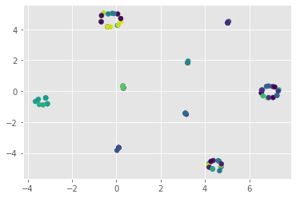

```python
# Creating the targets
target = one_hot_encoded_data_df[0].values

# Creating the features
features = one_hot_encoded_data_df.drop(0, axis = 1).values

#Initialize a TSNE object
tsne_object = TSNE()

transformed = tsne_object.fit_transform(features)

#Creating a t-SNE visualization
x_axis = transformed[:,0]
y_axis = transformed[:,1]

plt.scatter(x_axis, y_axis, c = target)
plt.show()
```

```python
# Selective correlated features
mode_cols = ['NAME', 'INTERESTED_PROJECT_AREA', 'UNDERGRAD_MAJOR', 'EMPLOYMENT_TYPE']
df_modes_new = df[mode_cols].iloc[:100];

# Set users as index
df_modes_new = df_modes_new.set_index('NAME');
```

## K Modes for Full Categorical Dataset with Cao

#### Selecting correlated features

#### Used K Modes to cluster the groups of students based on the categorical fields without encoding.

```python
def kModesClustering(inputDataset, method = 'Huang'):
    # Fit the cluster
    kmodes = KModes(n_jobs = -1, n_clusters = 34, init = method, random_state = 0)
    clusters = kmodes.fit_predict(inputDataset)
    return clusters

    # Cluster centorid
    # print(kmodes.cluster_centroids_)

    # Check the iteration of the clusters created
    # print(kmodes.n_iter_)

    # Check the cost of the clusters created
    # print(kmodes.cost_)


clusters = kModesClustering(df_modes_new, 'Huang')

clusters
```

```
array([ 2, 23, 28, 33, 27,  2, 14,  6, 12, 30,  6, 20,  0, 13,  1, 32,  3,
       29,  7, 10,  8, 19, 27, 24,  5, 10,  8, 22,  1, 28, 19, 13,  4, 32,
       21, 14, 17, 23, 20, 33, 11, 15,  7,  3,  2,  7,  6, 20, 16, 13,  4,
        5,  6, 31, 30, 23, 28,  8, 25, 31,  5, 12, 12, 30,  1,  8, 16, 26,
       24,  9,  6,  5, 18, 23, 32,  0, 26,  4,  9,  2, 14, 30,  6, 20, 33,
       28, 31,  5, 10, 12, 18,  8, 20, 13, 26, 24,  5, 10, 12,  7],
      dtype=uint16)
```

> Clusters using Huang method in K Modes

```python
clusters = kModesClustering(df_modes_new, 'Cao')

clusters
```

```
array([ 9,  7, 21,  6,  3,  9, 33,  4, 10,  1, 29,  0, 11, 31, 26,  8,  3,
       12, 20, 18,  0, 25,  3,  2, 17, 18,  5, 22, 26, 21, 25,  3,  2,  8,
       32, 33,  9,  7,  0,  6,  3, 13, 27,  4,  9, 20, 15,  0, 23,  3,  2,
       17,  4,  2,  1,  7, 21,  5,  3,  2, 17, 14,  5,  1, 26,  0, 23, 24,
        2, 30,  4, 19, 28,  7,  8, 11, 24,  2, 30,  9, 33,  1, 15,  0,  6,
       21,  2, 17, 18, 16, 28,  5,  0,  3, 24,  2, 17,  4, 16, 20],
      dtype=uint16)
```

> Clustered using Cao method in K Modes.

```python
# Elbow curve to find optimal K
cost = []
K = range(1,32)
for num_clusters in list(K):
    kmode = KModes(n_clusters=num_clusters, init = "random", n_init = 5, verbose=1);
    kmode.fit_predict(df_modes_new);
    cost.append(kmode.cost_);

plt.plot(K, cost, 'bx-')
plt.xlabel('No. of clusters')
plt.ylabel('Cost')
plt.title('Elbow Method For Optimal k')
plt.show()
```

[output not shown]

```python
# Selective correlated features
mode_cols = ['NAME', 'INTERESTED_PROJECT_AREA', 'UNDERGRAD_MAJOR', 'EMPLOYMENT_TYPE']
df_modes_new = df[mode_cols].iloc[:100];

# Set users as index
df_modes_new = df_modes_new.set_index('NAME');
```

```python
df[['NAME', 'INTERESTED_PROJECT_AREA', 'UNDERGRAD_MAJOR', 'EMPLOYMENT_TYPE']].set_index('NAME').head()
```

| NAME | INTERESTED_PROJECT_AREA | UNDERGRAD_MAJOR | EMPLOYMENT_TYPE |
| --- | --- | --- | --- |
| Stormy Muto | Food | FINE ARTS | Employed part-time |
| Carlos Ferro | Education | DRAMA AND THEATER ARTS | Independent contractor, freelancer, or self-em... |
| Robby Constantini | Travel | ACCOUNTING | Not employed, and not looking for work |
| Paul Mckenny | Crime | FINANCE | Not employed, but looking for work |
| Jean Webb | Music | COMPUTER PROGRAMMING AND DATA PROCESSING | Not employed, but looking for work |

```python
df_modes_new.insert(0, "Cluster_1", clusters, True)
# df_modes_new = df_modes_new.drop('Cluster_1', axis = True)
# df_modes_new = df_modes_new.reset_index().drop('NAME', axis = True)

df_modes_new[df_modes_new['Cluster_1'] == 2].head(5)
```

| NAME | Cluster_1 | INTERESTED_PROJECT_AREA | UNDERGRAD_MAJOR | EMPLOYMENT_TYPE |
| --- | --- | --- | --- | --- |
| Marcus Pettit | 2 | Sport | COMPUTER SCIENCE | Not employed, but looking for work |
| Stephen Bruno | 2 | Business | COMPUTER SCIENCE | Not employed, and not looking for work |
| Harland Gabe | 2 | Healthcare | COMPUTER SCIENCE | Not employed, and not looking for work |
| Patricia Harris | 2 | Crime | MEDICAL TECHNOLOGIES TECHNICIANS | Not employed, but looking for work |
| Rosemarie Turner | 2 | Crime | COMPUTER SCIENCE | Independent contractor, freelancer, or self-em... |

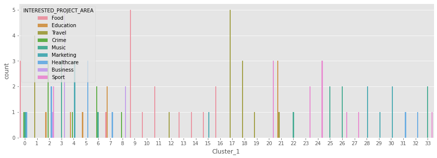

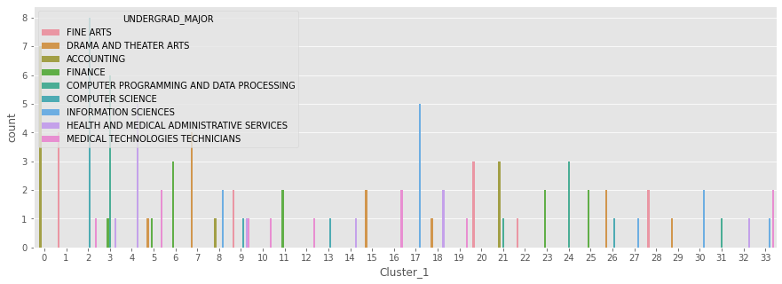

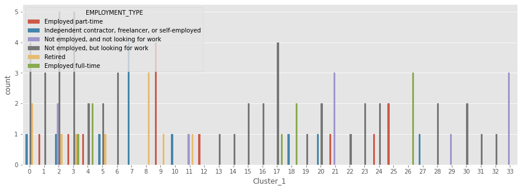

```python
for col in mode_cols:
    if col != 'NAME':
        plt.subplots(figsize = (15,5))
        sns.countplot(x='Cluster_1',hue=col, data = df_modes_new)
        plt.show()
```

> The graph above shows the count of users found clusterred based on each features i.e., **INTERESTED_PROJECT_AREA, UNDERGRAD_MAJOR, EMPLOYMENT_TYPE**

```python
# Selective correlated features
mode_cols = ['NAME', 'INTERESTED_PROJECT_AREA', 'EMPLOYMENT_TYPE', 'COUNTRY']
df_modes_new2 = df[mode_cols];

# Set users as index
df_modes_new2 = df_modes_new2.set_index('NAME')

clusters = kModesClustering(df_modes_new2, 'Cao')

df_modes_new2.insert(0, "Cluster_1", clusters, True)

df_modes_new2[df_modes_new2['Cluster_1'] == 2].head(5)
```

| NAME | Cluster_1 | INTERESTED_PROJECT_AREA | EMPLOYMENT_TYPE | COUNTRY |
| --- | --- | --- | --- | --- |
| Mary Armand | 2 | Travel | Not employed, but looking for work | Canada |
| Sharon Mosier | 2 | Healthcare | Not employed, but looking for work | Singapore |
| Peter Morales | 2 | Travel | Not employed, but looking for work | Morocco |
| Marsha Darrin | 2 | Travel | Not employed, but looking for work | Morocco |
| Jesse Tharpe | 2 | Crime | Not employed, but looking for work | Morocco |

```python
# Selective correlated features
mode_cols = ['NAME', 'INTERESTED_PROJECT_AREA', 'FORMAL_EDUCATION', 'EMPLOYMENT_TYPE']
df_modes_new3 = df[mode_cols];

# Set users as index
df_modes_new3 = df_modes_new3.set_index('NAME');

clusters = kModesClustering(df_modes_new3, 'Cao')

df_modes_new3.insert(0, "Cluster_1", clusters, True)

df_modes_new3[df_modes_new3['Cluster_1'] == 2].head(5)
```

| NAME | Cluster_1 | INTERESTED_PROJECT_AREA | FORMAL_EDUCATION | EMPLOYMENT_TYPE |
| --- | --- | --- | --- | --- |
| Jean Webb | 2 | Music | Some college/university study without earning ... | Not employed, but looking for work |
| Roberto Russell | 2 | Music | Secondary school (e.g. American high school, G... | Employed full-time |
| David Jared | 2 | Music | Secondary school (e.g. American high school, G... | Not employed, but looking for work |
| Juan Mitchell | 2 | Music | Other doctoral degree (Ph.D, Ed.D., etc.) | Not employed, but looking for work |
| Cheryl Minor | 2 | Music | Primary/elementary school | Employed part-time |

> Similarly, found the results above of the students teamed based on their **INTERESTED_PROJECT_AREA**, **FORMAL_EDUCATION**, **EMPLOYMENT_TYPE** that was found similar between these students.

```python
# Selective correlated features
mode_cols = ['NAME', 'INTERESTED_PROJECT_AREA', 'EMPLOYMENT_TYPE', 'AGE_GROUP']
df_modes_new4 = df[mode_cols];

# Set users as index
df_modes_new4 = df_modes_new4.set_index('NAME');

clusters = kModesClustering(df_modes_new4, 'Cao')

df_modes_new4.insert(0, "Cluster_1", clusters, True)

df_modes_new4[df_modes_new4['Cluster_1'] == 2].head(5)
```

| NAME | Cluster_1 | INTERESTED_PROJECT_AREA | EMPLOYMENT_TYPE | AGE_GROUP |
| --- | --- | --- | --- | --- |
| Laura Tofil | 2 | Business | Retired | 35-44 |
| Stephen Bruno | 2 | Business | Not employed, and not looking for work | 65-75 |
| Robert Edwards | 2 | Business | Employed full-time | 65-75 |
| Harland Gabe | 2 | Healthcare | Not employed, and not looking for work | 65-75 |
| Roger Palmer | 2 | Education | Not employed, and not looking for work | 65-75 |

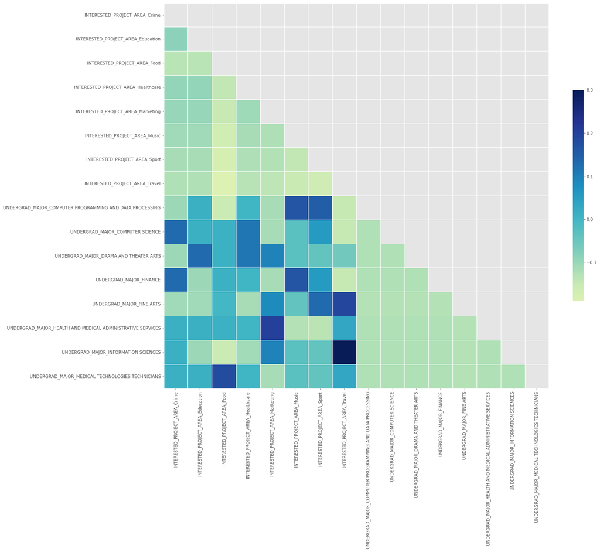

```python
corr = df_hot_sel_ohed.corr(method='spearman')
# Generate a mask for the upper triangle
mask = np.zeros_like(corr, dtype=np.bool)
mask[np.triu_indices_from(mask)] = True

# Set up the matplotlib figure
f, ax = plt.subplots(figsize=(20, 18))

# Draw the heatmap with the mask and correct aspect ratio
sns.heatmap(corr, mask=mask, cmap="YlGnBu", vmax=.30, center=0,
            square=True, linewidths=.5, cbar_kws={"shrink": .5})
```

> The above heatmap shows the correlation of the main feature i.e., **INTERESTED_PROJECT_AREA** to explain the similarity that can help the models to find the clusters.

# 9. sklearn.cluster

#### K Prototype on Semi Categorical Dataset

K-prototype is the one that we can use for clustering the data set which have both categorical and numerical vales. Students can be grouped by their interests and the education first. And base on them, when grouping is needed again after the first group project or a new project starts in a new semester, the professor can group them by additionally reflecting the assignment points and project scores that they previously received.

```python
kproto_df = df[['NAME', 'INTERESTED_PROJECT_AREA', 'FORMAL_EDUCATION', 'ASSIGNMENT_POINTS', 'PROJECT_SCORE']]

kproto_df = kproto_df.set_index('NAME')

kproto_df.head()

# kproto_df['PROJECT_SCORE'].unique()
```

| NAME | INTERESTED_PROJECT_AREA | FORMAL_EDUCATION | ASSIGNMENT_POINTS | PROJECT_SCORE |
| --- | --- | --- | --- | --- |
| Stormy Muto | Food | Bachelor’s degree (BA, BS, B.Eng., etc.) | 42 | 68 |
| Carlos Ferro | Education | Other doctoral degree (Ph.D, Ed.D., etc.) | 54 | 58 |
| Robby Constantini | Travel | Associate degree | 64 | 59 |
| Paul Mckenny | Crime | I never completed any formal education | 60 | 40 |
| Jean Webb | Music | Some college/university study without earning ... | 80 | 49 |

```python
# Model initialization
kP = KPrototypes(n_clusters = 13, init='Huang', n_init=1, verbose=True)

# Model prediction
kP_clusters = kP.fit_predict(kproto_df, categorical=[0,1])

kproto_df["Clusters"] = kP_clusters

# kP.cluster_centroids_

# kproto_df["Clusters"] = kP.labels_

kproto_df[kproto_df['Clusters'] == 1].head()
```

```
Init: initializing centroids
Init: initializing clusters
Init: initializing centroids
Init: initializing clusters
Starting iterations...
Run: 1, iteration: 1/100, moves: 10, ncost: 4922.369290999425
Run: 1, iteration: 2/100, moves: 3, ncost: 4840.984067904152
Run: 1, iteration: 3/100, moves: 1, ncost: 4824.882314895256
Run: 1, iteration: 4/100, moves: 0, ncost: 4824.882314895256
```

| NAME | INTERESTED_PROJECT_AREA | FORMAL_EDUCATION | ASSIGNMENT_POINTS | PROJECT_SCORE | Clusters |
| --- | --- | --- | --- | --- | --- |
| Carlos Ferro | Education | Other doctoral degree (Ph.D, Ed.D., etc.) | 54 | 58 | 1 |
| Robby Constantini | Travel | Associate degree | 64 | 59 | 1 |
| Danny Wilkinson | Marketing | Professional degree (JD, MD, etc.) | 56 | 70 | 1 |
| Ursula Kuehnert | Travel | I never completed any formal education | 68 | 57 | 1 |
| Lance Rochester | Music | Professional degree (JD, MD, etc.) | 64 | 70 | 1 |

#### Perform cluster analysis

```python
costs = []
n_clusters = []
clusters_assigned = []

for i in range(2, 10):
    try:
        kproto = KPrototypes(n_clusters= i, init='Cao', verbose=2)
        clusters = kproto.fit_predict(kproto_df, categorical=[0, 1])
        costs.append(kproto.cost_);
        n_clusters.append(i);
        clusters_assigned.append(clusters);
    except:
        print(f"Can't cluster with {i} clusters")

fig = go.Figure(data=go.Scatter(x=n_clusters, y=costs))
fig.show()
```

[output not shown]

[output not shown]

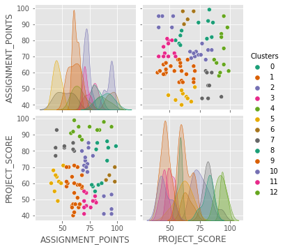

```python
kproto_df['Clusters'] = kP.labels_
print(kproto_df['Clusters'].value_counts())

sns.pairplot(kproto_df,hue='Clusters',palette='Dark2',diag_kind='kde')

# kproto_df
```

> The graph shows 13 groups were generated by close distances. This differentiation by score is useful for grouping students within similar levels such as beginner, intermediate, and advance and that way professor can assign suitable group projects to students who are classified into same level.

# 10. kNN Function

#### Feature selection on assignment marks to classify the students in groups

```python
kNN_df = df[['NAME']]

kNN_df[['Assignment_1st','Assignment_2nd','Assignment_3rd', 'Class']] = students_perf[['Assignment_1st','Assignment_2nd','Assignment_3rd', 'Class']]

kNN_df = kNN_df.set_index('NAME')

kNN_df.head()
```

| NAME | Assignment_1st | Assignment_2nd | Assignment_3rd | Class |
| --- | --- | --- | --- | --- |
| Stormy Muto | 72 | 72 | 74 | group B |
| Carlos Ferro | 69 | 90 | 88 | group C |
| Robby Constantini | 90 | 95 | 93 | group B |
| Paul Mckenny | 47 | 57 | 44 | group A |
| Jean Webb | 76 | 78 | 75 | group C |

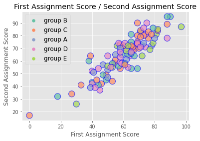

```python
# Sepal scatter visualization
sns.scatterplot('Assignment_1st', 'Assignment_2nd', data = kNN_df, hue = 'Class', palette = 'Set2', edgecolor = 'b', s = 150,
               alpha = 0.7)
plt.title('First Assignment Score / Second Assignment Score')
plt.xlabel('First Assignment Score')
plt.ylabel('Second Assignment Score')
plt.legend(loc = 'upper left', fontsize = 12)
plt.show()
```

> The graph above depicts the relation between the assignment scores of the formed teams in the order that would help model predict the final scores.

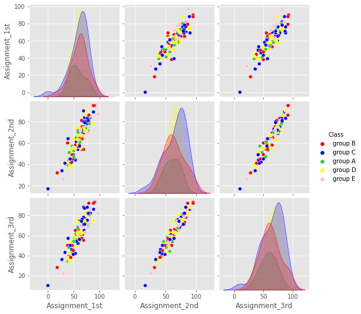

```python
# Scatter Matrix
sns.pairplot(data = kNN_df, hue = 'Class', palette = ['Red', 'Blue', 'limegreen', 'yellow', 'pink'])
```

> The graph above shows the correlation betweeen the assignments score betwee 1st, 2nd and 3rd between the groups as label shows in legend.

```python
# Your function returns the classification of your data-point
def kNN(kNN_df, input_point):
    X_var = kNN_df[['Assignment_1st', 'Assignment_2nd', 'Assignment_3rd']].values
    y_var = kNN_df['Class'].values

    # X_var = StandardScaler().fit(X_var).transform(X_var.astype(float))

    X_train, X_test, y_train, y_test = train_test_split(X_var, y_var, test_size = 0.2, random_state = 0)

    k = 5

    neigh = KNeighborsClassifier(n_neighbors = k)
    neigh.fit(X_train, y_train)

    yhat = neigh.predict(X_test)
    err = round(accuracy_score(y_test, yhat)*100, 2)

    classification_point = neigh.predict(pd.DataFrame(input_point, index= [i for i in range(len(d))]))
    return classification_point
```

```python
# Input data points
d = [
    {'Assignment_1st': 50,'Assignment_2nd': 44,'Assignment_3rd': 45},
    {'Assignment_1st': 80,'Assignment_2nd': 94,'Assignment_3rd': 95},
]

# Function call with dataset to train and input data points to predict
kNN(kNN_df, d)
```

```
array(['group C', 'group B'], dtype=object)
```

> The kNN function above returns the classification of given data-points.

> Based on assignment scores students are grouped in 'C' and 'B' repspectively.

# 11. Project Report

#### 10 paragraphs and a few plots. Your report should be addressed to your stakeholder and the analysis should be relevant to them.

#### Our motive behind this project is that students can find others who can be their best versions as a project partner

The focal point of our project is to club students in such a way that working in a project in fact increases their productivity. Our Stakeholer Canvas, is a Learning Management System (LMS portal) that is used by universities to help students focus on education rather than simply understanding how to navigate the system. It allows both students and professors to keep track of how the subjects are progressing. We would like to suggest the Machine Learning Clustering Algorithm to help sort students into appropriate teams so that they can achieve a productive result.

Our dataset consists of categorical and numerical values which are needed for our clustering model to club students based on interests and assignments and project scores. If we check below we can see the different areas that students are interested and also the scores they secured in assignments and projects

```python
df.head(4)
```

|  | NAME | INTERESTED_PROJECT_AREA | AGE_GROUP | EMPLOYMENT_TYPE | FORMAL_EDUCATION | UNDERGRAD_MAJOR | MAJOR_CATEGORY | ASSIGNMENT_POINTS | PROJECT_SCORE | COUNTRY |
| --- | --- | --- | --- | --- | --- | --- | --- | --- | --- | --- |
| 0 | Stormy Muto | Food | 45-54 | Employed part-time | Bachelor’s degree (BA, BS, B.Eng., etc.) | FINE ARTS | Arts | 42 | 68 | United Kingdom |
| 1 | Carlos Ferro | Education | 35-44 | Independent contractor, freelancer, or self-em... | Other doctoral degree (Ph.D, Ed.D., etc.) | DRAMA AND THEATER ARTS | Arts | 54 | 58 | United Kingdom |
| 2 | Robby Constantini | Travel | 45-54 | Not employed, and not looking for work | Associate degree | ACCOUNTING | Business | 64 | 59 | United Kingdom |
| 3 | Paul Mckenny | Crime | 18-24 | Not employed, but looking for work | I never completed any formal education | FINANCE | Business | 60 | 40 | Germany |

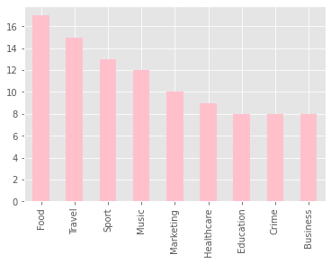

```python
df['INTERESTED_PROJECT_AREA'].value_counts().plot(kind='bar', color='pink')
```

When we consider students pursuing a Master's degree we can say that everyone comes in froma. different background too. So there is a possibility that if its a technical subject a student from bio-chemistry background will take some time to crack the subject and might score a bit less than the one who has a degree in a technical background. So we have represented the corelation between Students background and their assignment marks scored.

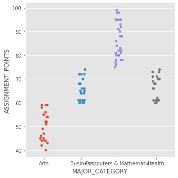

```python
plt.figure(figsize=(10,5))

sns.catplot(data=df, x="MAJOR_CATEGORY", y="ASSIGNMENT_POINTS")

# Show the graph
plt.show()
```

We have also taken into consideration interested area of students as well. So we need to understand the corelation of that with Assignments Scores so that we can show if at all the interested area can define what kind of score the student will get. The below visualization shows that it doesn't define any student as to what score they might. Also we can see that students can easily score a 80 and above score as well as a decent score of 70 and up.

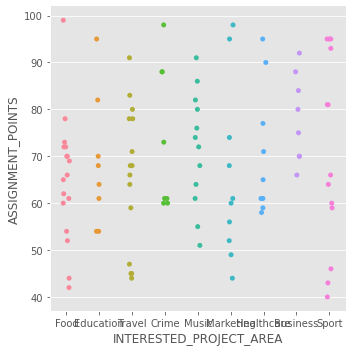

```python
plt.figure(figsize=(10,5))

# plt.scatter(list(df.ASSIGNMENT_POINTS.values),list(df.INTERESTED_PROJECT_AREA.values),color='r')
sns.catplot(data=df, x="INTERESTED_PROJECT_AREA", y="ASSIGNMENT_POINTS")

# Show the graph
plt.show()
```

We have also mentioned that our another factor for proffessors would be the project score. We want our model to also show the productivity of teams if they work again on a different project as well. The below graph shows the project score on interested are for the professor to decide which area has earned high score and can have advance tasks assigned.

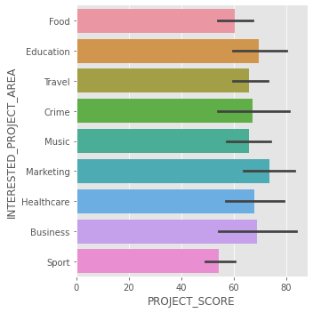

```python
sns.catplot(data=df, x="PROJECT_SCORE", y="INTERESTED_PROJECT_AREA", kind="bar")
```

For Clustering algorithms, we need numerical data which can help the machine learning models take in the equivalent numerical values of those categorical values and can give us a better clustering result. We have used Label encoding and One-Hot encoding methods to convert those categorical values into numerical ones.

For the first run we have clustered our data to find out what the optimal K would be and based on that we want to now cluster students based on semi categorical data wherein we consider not just interested area and formal education but also factor in their assignemnt and project scores too. So the below visualisation depicts the same.

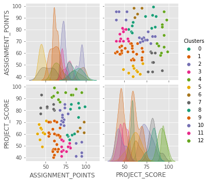

```python
sns.pairplot(kproto_df,hue='Clusters',palette='Dark2',diag_kind='kde')
```

Coming back to our focal point - to help students choose partents who can achieve a productive result we have used knn algorithm to cluster the students based on their assignment marks to again club students. We wanted the proffessors to have this feature available to them just in case they needed Underperforming stuents to collaborate who have not been that vocal about their interested areas or help the professors understand the productivity of the same project teams working on the 2nd project.

```python
d = [
    {'Assignment_1st': 50,'Assignment_2nd': 44,'Assignment_3rd': 45},
    {'Assignment_1st': 80,'Assignment_2nd': 94,'Assignment_3rd': 95},
]

kNN(kNN_df, d)
```

```
array(['group C', 'group B'], dtype=object)
```

The idea of this project has been plain and simple which is just for students to find better companionship in their project partners. Honestly, our model does help not just the students but also the professors to club students in such an effective way that everyone can enjoy working with different people and also deliver unique and qualitative projects which they can showcase in their portfolios

# Professionalism

#### Titles and text are professional. Code is organized within their respective titles. Code is explained with words. Plots are explained with words.

This projects code and results have been explained clearly with text and have detailed text on the idea we focused on. The objectives are shown clearly and explained breifly in summary after every result was obtained. The code are explained in comments above each code lines and plots are explained with short text below it.

Also, To keep it professional we strictky followed the provided rubric and named the titles and ordered in the exact fasion.

# Originality